# *CSP* et *nQueens*

Hugues Santerre

# 1. *CSP*

Les algorithmes de *CSP* peuvent résoudre des problèmes d’**optimisation** semblable à ceux résolus par les algorithmes de **programmation linéaire**.

Un module comme PuLP ou Python-MIP pourrait résoudre des problèmes de *CSP* et vice-versa.

# 1. *CSP* (suite)

**Objectif:** résoudre un problème où chaque **variable** possède une **valeur** qui satisfait certaines **contraintes**.

Par exemple: colorier chaque territoire sans que deux territoires n’aient une couleur similaire (source: https://samgriesemer.com/Constraint_satisfaction_problems).

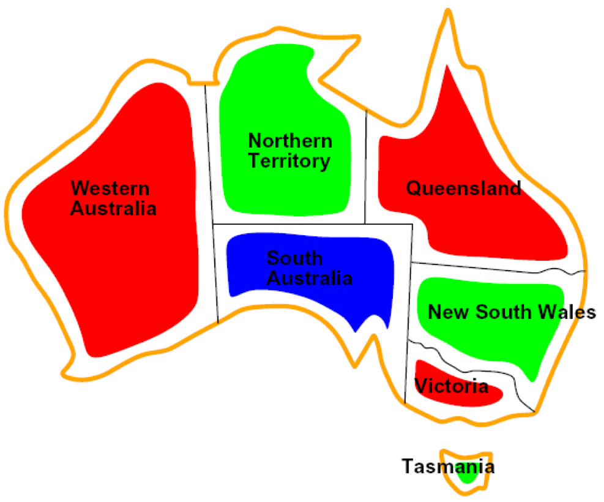

# 1. *CSP* (fin)

En comparaison de la programmation linéaire, l’approche *CSP* s’apparente plus aux **graphes**. La résolution du problème implique donc un parcours dans un graphe.

Le parcours consiste à colorer chaque noeud, un après l’autre, mais aussi à vérifier que chaque noeud ne soit pas de la même couleur que ses voisins.

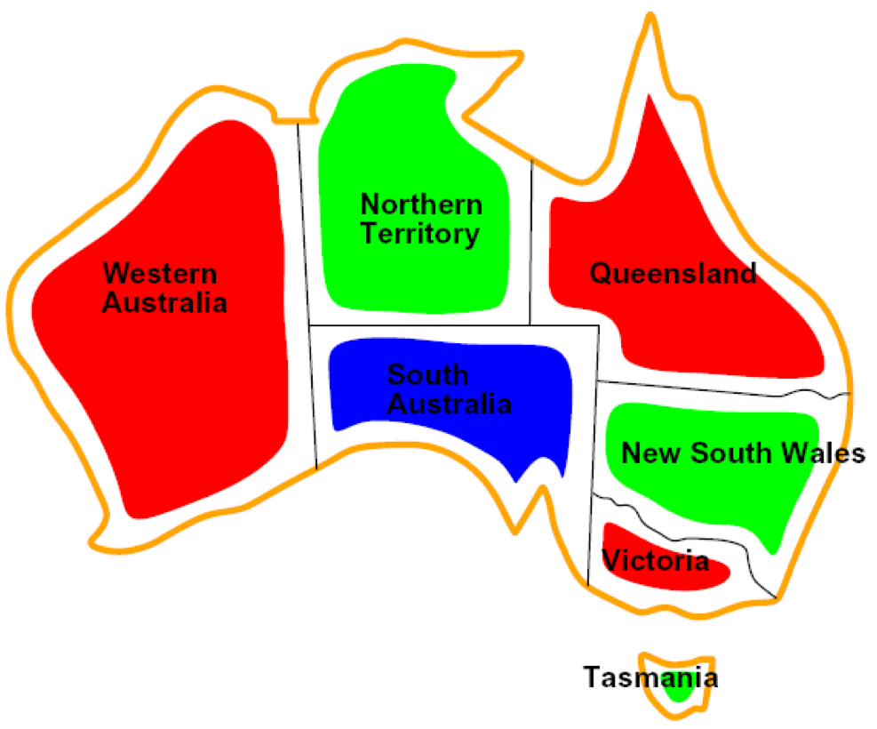

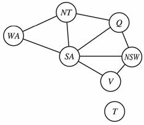

# 2. nQueens

C’est un problème classique qui consiste à positionner des dames sur un échiquier sans qu’aucune dame ne puisse attaquer une autre dame (source: https://en.wikipedia.org/wiki/Eight_queens_puzzle).

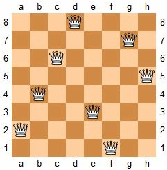

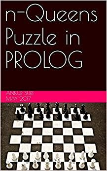

Ce problème est résoluble avec la programmation linéaire ou l’approche *CSP*; avec de nombreux langages de programmation (jeunes et moins jeunes).

# 2. Approche *CSP* pour *nQueens*

**Objectif:** résoudre un problème où chaque **variable**, une dame dans chaque colonne de l’échiquier, possède une **valeur**, une rangée, qui satisfasse certaines **contraintes**: la position de chaque dame ne permet pas d’attaquer les autres dames. Expérimenter avec Pychess:

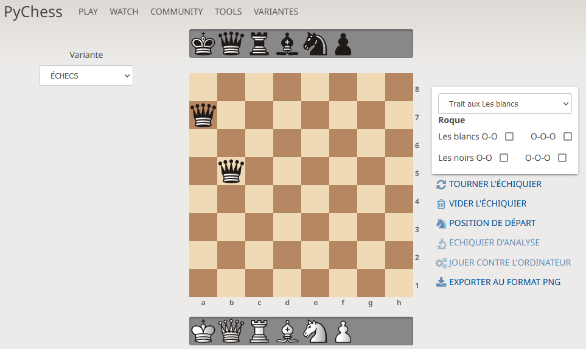

# 2. Composants du *CSP*

- Un ensemble de **variables** (a, b, c)
- Un ensemble de **domaines** avec des **valeurs** (1, 2, 3); un domaine pour chaque variable (a: (1, 2, 3)); les variables peuvent avoir le même domaine (1, 2, 3) ou des domaines différents (a: (1, 2, 3), b: (1, 2) et c: (1, 3))
- Un ensemble de **contraintes** que doivent respecter les valeurs attitrées à chaque variable (si a == 1, alors b != 1 ou b > 1)

Source: https://www.tutorialandexample.com/constraint-satisfaction-problems-in-artificial-intelligence

# 2. Composants du *nQueens*

- Les **variables** sont les dames (4 dames sur un échiquier 4x4 … 8 dames sur un échiquier 8x8) et chaque dame occupe une colonne (de 1 à 4 … de 1 à 8)
- Le **domaine** de chaque variable, de chaque dame sur 1 colonne, est le valeur de la rangée (de 1 à 4 … de 1 à 8)

# 2. Composants du *nQueens* (suite)

- Chaque dame occupe une colonne différente (ce qui prévient, par défaut, une attaque verticale et satisfait une des **contraintes**)
- Une autre **contrainte** est qu’il ne peut y avoir qu’une seule dame sur la même rangée pour éviter une attaque horizontale; on teste qu’il n’y a qu’une game par rangée

# 2. Composants du *nQueens* (fin)

- La dernière **contrainte** est celle des diagonales
- On teste l’alignement diagonal de 2 dames en évaluant si la distance verticale absolue est égale à la distance horizontale absolue; une dame en (1,1) et une dame en (4,4) donne |4 - 1| = 3 et |4 - 1| = 3, donc 3 == 3 (alignement diagonal)

# 2. Algorithme

Le principal algorithme utilisé est celui du *Backtracking Search*.

L’algorithme fonctionne selon les principes d’une recherche dans un **graphe**.

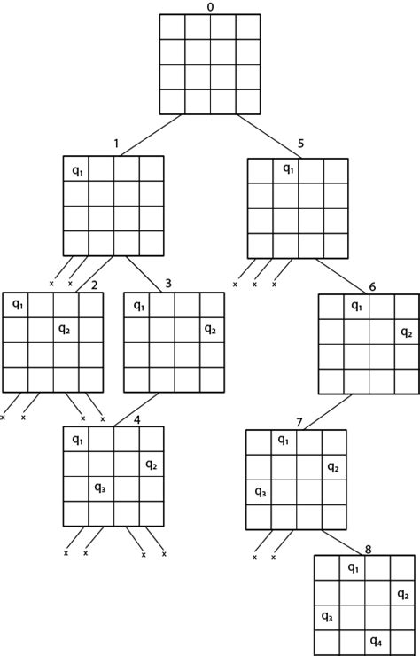

# 2. Algorithme (suite)

Les positions retenues respectent les **contraintes**.

Les positions retenues sont gardées dans un dictionnaire. Ci-dessus: `{1:2, 2:4, 3:1, 4:3}`.

L’algorithme trouve une solution quand le dictionnaire est rempli: un échiquier de 4x4, 4 dames, 4 `clés:valeurs`.

# 2. Algorithme (suite)

Si l’algorithme n’arrive pas à trouver 4 `clés:valeurs` respectant les contraintes ou du moment qu’il bloque parce qu’il est impossible de placer une nouvelle dame selon les contraintes, l’algorithme expulse une à une les `clés:valeurs` du dictionnaire.

C’est le “retour en arrière” (*Backtracking*). L’algorithme peut aller jusqu’à purger le dictionnaire.

L’algorithme recommence le premier placement de dame pour tenter une autre combinaison.

# 2. Algorithme (suite)

Au plus simple, le *Backtracking Search* commence avec une 1re dame sur la 1re colonne en 1re rangée. Le choix de la rangée suit un **ordre statique**. Sur la 2e colonne, l’algorithme débute avec une 2e dame et teste la 1re rangée, puis la 2e rangée, ainsi de suite. Par la suite, l’algorithme passe à la 3e colonne, la 3e dame et ainsi de suite.

L’**ordre de placement** peut aussi être **aléatoire**. L’algorithme place la 2e dame en 2e colonne sur une des rangées au hasard, puis teste une autre rangée, etc.

# 2. Algorithme (suite)

Le **premier placement** est imposé: une 1re dame sur la 1re colonne, sur la 1re rangée.

Les placements suivant sont ordonnés suivant le premier placement: de la 2e colonne à la dernière colonne.

Puis, pour chaque colonne, l’algorithme tente des positions (des rangées) en ordre statique ou aléatoire et arrête ses choix quand les contraintes sont respectées (source: https://samgriesemer.com/Constraint_satisfaction_problems).

# 2. Algorithme (suite)

Avant un nouveau placement, il y a une division: des dames sont déjà **assignées** dans des colonnes (les position sont dans le dictionnaire de solution) ou **non assignées** dans d’autres colonnes.

On compare la dame **non assignée** nouvellement assignée avec les autres dames déjà **assignées**.

# 2. Algorithme (suite)

Pour chaque tentative de placement, il y a évaluation des contraintes avec la nouvelle dame et les dames déjà en place. Est-ce que le placement **satisfait** les contraintes: est-ce orthogonal, est-ce diagonal ou est-ce un bon placement ?

La contrainte verticale n’est jamais évaluée puisque chaque dame occupe une colonne différente par défaut.

# 2. Algorithme (fin)

Le *Backtracking Search* est à la base un algorithme récursif non informé (sans heuristique). Donc, il explore en profondeur: il prend une colonne (un noeud parent) et explore ses rangées (ses noeuds enfants).

# 3. Améliorer l’algorithme

Il existe des **améliorations** pour accélérer la recherche du *Backtracking Search*: *Forward Checking*, *Constraint Propagation* et *K-Consistency*.

Grosso modo, le *Backtracking Search* explore des solutions condamnées d’avance. Les améliorations permettent d’éviter ces culs-de-sac en élaguant le graphe. Il y a moins de noeuds à tester; ce qui accélère la recherche (source: https://samgriesemer.com/Constraint_satisfaction_problems).

# 3. Heuristiques

L’**ordre statique** ou **aléatoire** n’est pas **optimal**, i.e., il font trop d’essais et d’erreurs inutiles.

Il existe des **heuristiques** pour orienter le placement des dames; ce qui accélère la recherche.

Le *Minimum Remaining Values* (*MRV*) fonctionne avec un filtre qui élimine du domaine des prochaines variables (des prochaines dames à être placée) les rangées déjà occupées. Le *MRV* calcule la taille de tous les domaines, puis sélectionne la dame avec le plus petit domaine pour le placement suivant (source: https://samgriesemer.com/Constraint_satisfaction_problems).

# 3. Heuristiques (fin)

Le *Least Constraining Value* (*LCV*) évalue chacune des positions de la dame suivante, dans la colonne choisie.

Le *LCV* cherche la rangée où cette dame minimise le nombre de conflits Par exemple, dans une rangée, une dame peut avoir 3 alignements avec d’autres dames. Le résultat idéal est 0, mais 1 peut donner un placement temporaire qui sera revu plus tard.

L’heuristique permet à l’algorithme de fouiller les possibilités de façon informée. Les résultats du *LCV* diminuent au fur et à mesure que la recherche avance jusqu’à donner 0 lorsque l’algorithme tend vers la solution.

# 4. Solutions et observations

Avec certaines observations, on peut trouver des **raccourcis**. D’abord, voici le nombre de solutions connues:

| Échiquier | Solutions | Uniques |  | Échiquier | Solutions | Uniques |
| --- | --- | --- | --- | --- | --- | --- |
| 1x1 | 1 | 1 |  | 5x5 | 10 | 2 |
| 2x2 | 0 | 0 |  | 6x6 | 4 | 1 |
| 3x3 | 0 | 0 |  | 7x7 | 40 | 6 |
| 4x4 | 2 | 1 |  | 8x8 | 92 | 12 |

En éliminant les symétries dans les solutions, on retrouve les solutions uniques (source: https://durangobill.com/N_Queens.html)

# 4. Solutions et observations (fin)

- Un échiquier pourrait montrer la même configuration 4 fois en pivotant le plateau de 90, 180 et 270 degrés
- L’échiquier de gauche est symmétrique à l’échiquier de droit par réflection horizontale et verticale

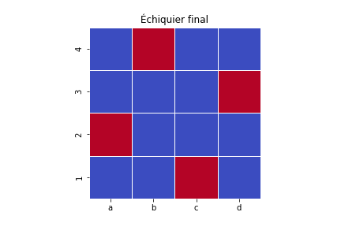

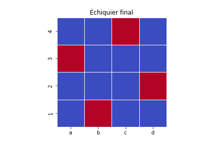

# 4. Sans filtre, sans heuristique (suite)

Dans les solutions, on remarque que les dames occupent rarement les **coins**.

```
[[Q...., ...Q., .Q..., ....Q, ..Q..], [Q...., ..Q.., ....Q, .Q..., ...Q.],
[..Q.., Q...., ...Q., .Q..., ....Q], [...Q., Q...., ..Q.., ....Q, .Q...],
[.Q..., ...Q., Q...., ..Q.., ....Q], [....Q, ..Q.., Q...., ...Q., .Q...],
[.Q..., ....Q, ..Q.., Q...., ...Q.], [....Q, .Q..., ...Q., Q...., ..Q..],
[...Q., .Q..., ....Q, ..Q.., Q....], [..Q.., ....Q, .Q..., ...Q., Q....]]
```

# 4. Sans filtre, sans heuristique (fin)

Il n’y a pas de solution avec dame au coin en 4x4.

Bref, une dame au coin est rare !

Pourquoi alors imposer la 1re dame au coin (position 1,1) au démarrage?

# 5. Changer l’ordre

On peut accélérer la recherche du *Backtracking Search* en imposant la 1re dame sur la **2e colonne**, en 1re rangée. Les colonnes suivantes seront 1re, puis 3e et 4e. C’est toujours un **ordre statique** (ou **aléatoire**); pour les rangées.

Ce changement élimine des parcours infructueux; la construction de dictionnaires de solutions et des “retours en arrière” inutiles.

# 5. Modèles

Les modèles testés utilisent un Backtracking Search avec **départ à la 1re colonne (1,1)** et un comparatif avec **départ à la 2e colonne (2,1)**.

# 5. Résultats

Les 2 modèles utilisés ne sont pas optimaux et ne trouvent qu’une solution parmi l’ensemble de solutions.

Cependant, le 2e modèle (BS2) est toujours plus rapide!

Il fait moins d’essais (on imprime moins de *Lines of code* ou *LOC* qui montrent tous les essais) et on arrive à la solution plus rapidement (on montre un chrono plus rapide).

Les temps estimés sont ceux d’un processeur Intel i5 5e génération. C’est plutôt le comparatif entre les temps qui est intéressant.

# 5. Résultats (suite)

Modèle BS

| Échiquier | LOC | Chrono (s) |
| --- | --- | --- |
| 4x4 | 1047 | 0.959531 |
| 6x6 | 18503 | 17.493276 |
| 8x8 | 209942 | 179.305351 |

Modèle BS2

| Échiquier | LOC | Chrono (s) |
| --- | --- | --- |
| 4x4 | 347 | 0.516618 |
| 6x6 | 12996 | 9.749945 |
| 8x8 | 90256 | 72.346662 |

Sur un processeur Intel i5 5e génération.

# 5. Résultats (suite)

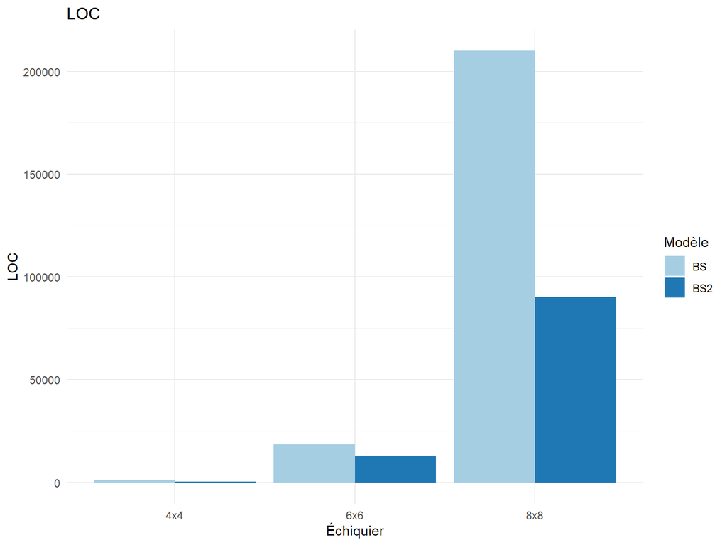

Sur un processeur Intel i5 5e génération.

# 5. Résultats (fin)

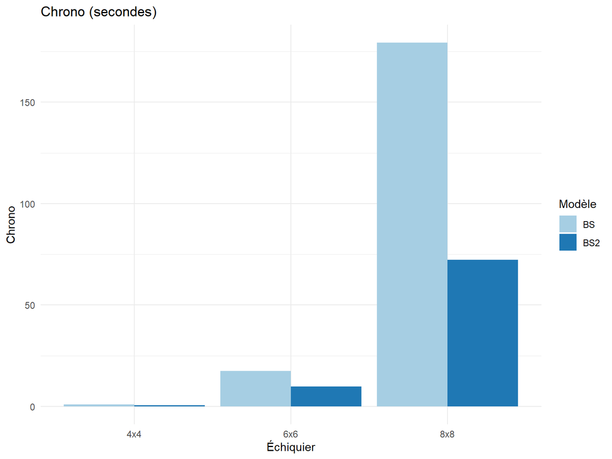

Sur un processeur Intel i5 5e génération.

# 5. Autres raccourcis

Il existe probablement d’autres raccourcis de ce genre qui permettent à l’algorithme, sans élagage, sans heuristique, de converger plus rapidement vers une solution si le but n’est que de trouver une des solutions et non toutes les solutions.

Ce sont des agencements qui mènent à des culs-de-sac qui pourraient être évalués comme des contraintes.

Par exemple, on pourrait noter les diagonales comme les colonne et limiter 1 dame par colonne et diagonale.

# 6. Comparatif avec Python-MIP

Le 2e modèle (BS2) trouve une solution à 4 dames en moins de 1s, mais met environ 72s pour trouver une solution à 8 dames.

Python-MIP est un module de programmation linéaire et mixte. C’est une approche beaucoup plus récente que l’approche *CSP* (obsolète).

Avec une boucle, sur le même processeur Intel i5 5e génération, MIP trouve 1 solution (*nQueens*) pour chaque cas de 3 à 8 dames… en moins de 14s!